# Data normalization

## Initialization

```r
library(DT)
library(tidyverse)
library(data.table)
library(WriteXLS)
library(ggrepel)
library(ggpubr)
library(patchwork)
library(pheatmap)
library(RColorBrewer)
path = "/Users/ashwin/Documents/Projects/YeastScreen/Essential_DAmP_screen/"
```

## Normalization methodology

We use two different normalization strategy to answer specific questions -

- For a given plate $i$, the Cytoplasmic and Mitochondrial roGFP2 ratios are normalized by the median of all controls in the same plate i.e for cytoplasm -
  $$NormCyto(i) = \frac{Cyto_i} {median(Ctrl_i)}$$
  and for mitochondria,
  $$NormMito(i) = \frac{Mito_i} {median(Ctrl_i)}$$

> This type of control based plate normalization will be suitable in comparing the redox levels in across organells and nutrients since the roGFP2 ratios has been commonly normalized to the plate control.
- For a given plate $i$ with the Cytoplasmic and Mitochondrial roGFP2 ratios $j$ are normalized by their respective plate specific median roGFP2 ratios i.e for cytoplasm -
  $$NormCyto_{i} = \frac{Cyto_{ij} - median(Cyto_{i})} {mad(Cyto_{i})}$$
  and for mitochondria,
  $$NormMito_{i} = \frac{Mito_{ij} - median(Mito_{i})} {mad(Mito_{i})}$$

> This type of organelle specific normalization will be suitable in comparing the redox levels in each organelle across all plates. Since this type of normalization tells us how far are the values from the plate median.

Eventually, we generate the following -

- A table with all the replicate values per organelle and nutrient conditions and the the median summarized value from all plates
- A matrix with gene/mutants in rows and all combinations of organelle, nutrient and replicates (and median summarized value) in the column

Below is the table of cleaned raw data that we will use in our analysis.

```r
rawDatCleaned = readRDS(paste0(path, "data/workspaces/YeastRedox_DAmP_RawData_ForZNorm.RDS"))
rawDatCleaned = rawDatCleaned[,c("Plate", "Well_96", "Well", "Group", "Content",
                                 "SystematicName", "SGD.ID", "Gene.Symbol",
                                 "roGFP2.ratio", "Type")]

rawDatCleaned_ctrlfilt = readRDS(paste0(path, "data/workspaces/YeastRedox_DAmP_RawData_ForCtrlNorm.RDS"))
rawDatCleaned_ctrlfilt = rawDatCleaned_ctrlfilt[,c("Plate", "Well_96", "Well", "Group", "Content",
                                                   "SystematicName", "SGD.ID", "Gene.Symbol",
                                                   "roGFP2.ratio", "Type")]

normalizeScreenData = function(normMethod)
{

  if(normMethod == "fracControl"){
    normDat = split(rawDatCleaned_ctrlfilt, as.character(rawDatCleaned_ctrlfilt$Type))
    normDat = lapply(normDat, function(x) {
    split(x, x$Plate)})
  }

  if(normMethod == "robustZ"){
    normDat = split(rawDatCleaned, rawDatCleaned$Type)
    normDat = lapply(normDat, function(x) {
    split(x, x$Plate)})
  }

  normDatReps = normDat

  for (i in 1:length(normDat))
  {
    for (j in 1:length(normDat[[i]]))
    {
      tmp = droplevels(normDat[[i]][[j]])

      if(nrow(tmp) > 0) #since there are no entries from plate 150, was filtered in previous step
      {

      #---------------------------------------------------------------------------------------------
      # Separate Controls, Cytoplasam and Mitochondrial roGFP2 ratios per plate
      #---------------------------------------------------------------------------------------------

      # Control
      tmp.ctrl = droplevels(tmp[tmp$Content == "Control",])

      # Cytoplasm
      tmp.cyto = droplevels(tmp[tmp$Content == "Cytoplasm",])

      # Mitochondria
      tmp.mito = droplevels(tmp[tmp$Content == "Mitochondria",])

      rm(tmp)

      #---------------------------------------------------------------------------------------------
      # Compute the corresponding normalization factors (median & median absolute deviation)
      #---------------------------------------------------------------------------------------------

      # Normalizing factor - Control
      nf.ctrl.med = median(tmp.ctrl$roGFP2.ratio, na.rm = T)

      # Normalizing factor - Cytoplasm
      nf.cyto.med = median(tmp.cyto$roGFP2.ratio, na.rm = T)
      nf.cyto.mad = mad(tmp.cyto$roGFP2.ratio, na.rm = T)

      # Normalizing factor - Mitochondria
      nf.mito.med = median(tmp.mito$roGFP2.ratio, na.rm = T)
      nf.mito.mad = mad(tmp.mito$roGFP2.ratio, na.rm = T)

      #---------------------------------------------------------------------------------------------
      # The two normalization strategies (plate control and median based)
      #---------------------------------------------------------------------------------------------

      # Normalization 1 - Plate control based
      if (normMethod == "fracControl")
      {
        tmp.cyto$roGFP2.ratio = tmp.cyto$roGFP2.ratio / nf.ctrl.med
        tmp.mito$roGFP2.ratio = tmp.mito$roGFP2.ratio / nf.ctrl.med
      }

      # Normalization 2 - Plate median based
      if (normMethod == "robustZ")
      {
        tmp.cyto$roGFP2.ratio = (tmp.cyto$roGFP2.ratio - nf.cyto.med) / nf.cyto.mad
        tmp.mito$roGFP2.ratio = (tmp.mito$roGFP2.ratio - nf.mito.med) / nf.mito.mad
      }

      rm(nf.ctrl.med,
         nf.cyto.med,
         nf.cyto.mad,
         nf.mito.med,
         nf.mito.mad)

      #---------------------------------------------------------------------------------------------
      # Normalized data with replicates - coverting from long to wide table format
      #---------------------------------------------------------------------------------------------

      #---Cytoplasm---#

      tmp.cyto.repl = tmp.cyto %>%
        select(Gene.Symbol, Plate, Group, roGFP2.ratio, Type, Content) %>%
        group_by(Gene.Symbol, Group) %>%
        mutate(pseurep = paste0("roGFP2_ratio_", 1:n())) %>%
        spread(key = pseurep, value = roGFP2.ratio) %>%
        ungroup() %>%
        select(-Group) %>%
        rename(Genes = Gene.Symbol,
               Nutrient = Type,
               Organelle = Content)

      #---Mitochondria---#

      tmp.mito.repl = tmp.mito %>%
        select(Gene.Symbol, Plate, Group, roGFP2.ratio, Type, Content) %>%
        group_by(Gene.Symbol, Group) %>%
        mutate(pseurep = paste0("roGFP2_ratio_", 1:n())) %>%
        spread(key = pseurep, value = roGFP2.ratio) %>%
        ungroup() %>%
        select(-Group) %>%
        rename(Genes = Gene.Symbol,
               Nutrient = Type,
               Organelle = Content)

      #--Compilation---#

      normDatReps[[i]][[j]] = rbind(tmp.cyto.repl, tmp.mito.repl)

      #Deleting
      rm(tmp.ctrl,
         tmp.cyto,
         tmp.mito,
         tmp.cyto.repl,
         tmp.mito.repl)
      }
    }
   rm(j)
  }
  rm(i)

  res = lapply(normDatReps, function(x) {
    x = do.call("rbind", x)
    x = as.data.frame(x)
    x$Plate     = factor(x$Plate)
    x$Organelle = factor(x$Organelle, levels = c("Mitochondria", "Cytoplasm"))
    x$Nutrient  = factor(x$Nutrient, levels = c("Glucose", "Galactose", "Glycerol"))
    rownames(x) = 1:nrow(x)
    return(x)
  })

  res = do.call("rbind", res)

  #-------------------------------------------------------------------------------------------------
  # Summarizing mutiple mutants (i.e same gene) from the same or different plates
  # Also dropping genes with 2 or more NA values
  # For genes with just 1 NA value, replacing it with the median of the remaining 3 observed values
  #-------------------------------------------------------------------------------------------------

  res = res %>%
    rowwise() %>%
    mutate(Median_roGFP2_ratio = median(c(roGFP2_ratio_1, roGFP2_ratio_2, roGFP2_ratio_3, roGFP2_ratio_4), na.rm=T),
           NA_per_row = sum(is.na(c(roGFP2_ratio_1, roGFP2_ratio_2, roGFP2_ratio_3, roGFP2_ratio_4)))) %>%
    filter(NA_per_row < 2) %>%
    ungroup() %>%
    mutate_at(vars(starts_with("roGFO2_ratio_")),
     function(x) ifelse(is.na(x), .$Median_roGFP2_ratio, x)) %>%
    select(-NA_per_row) %>%
    group_by(Organelle, Nutrient, Genes) %>%
    top_n(n=1, abs(Median_roGFP2_ratio)) %>%
    ungroup()

  #-------------------------------------------------------------------------------------------------
  # Compiling all replicates across organelles and nutrient conditions into a single matrix
  #-------------------------------------------------------------------------------------------------

  redoxMat = data.table(res[,c("Genes", "Nutrient", "Organelle", "roGFP2_ratio_1", "roGFP2_ratio_2", "roGFP2_ratio_3", "roGFP2_ratio_4")])
  redoxMat = dcast(redoxMat, Genes ~ Organelle + Nutrient, fun.aggregate = function(x){x}, fill=NA,
              value.var = c("roGFP2_ratio_1", "roGFP2_ratio_2", "roGFP2_ratio_3", "roGFP2_ratio_4"))
  redoxMat = redoxMat[,c(1,
               2,8,14,20,
               3,9,15,21,
               4,10,16,22,
               5,11,17,23,
               6,12,18,24,
               7,13,19,25
               )]
  redoxMat = data.frame(redoxMat, stringsAsFactors = F )
  rownames(redoxMat) = redoxMat$Genes
  redoxMat = redoxMat[,-1]

  #-------------------------------------------------------------------------------------------------
  # Compiling the median values across organelles and nutrient conditions into a single matrix
  #-------------------------------------------------------------------------------------------------

  redoxMat_median = data.table(res[,c("Genes", "Nutrient", "Organelle", "Median_roGFP2_ratio")])
  redoxMat_median = dcast(redoxMat_median, Genes ~ Organelle + Nutrient, fun.aggregate = function(x){x}, fill=NA,
                    value.var = "Median_roGFP2_ratio")

  redoxMat_median = data.frame(redoxMat_median, stringsAsFactors = F )
  rownames(redoxMat_median) = redoxMat_median$Genes
  redoxMat_median = redoxMat_median[,-1]

  #-------------------------------------------------------------------------------------------------
  # Putting all the results into one
  #-------------------------------------------------------------------------------------------------

  res = list(redox_table = res, redox_replicates = redoxMat, redox_median = redoxMat_median)
  rm(normDat, normDatReps, redoxMat, redoxMat_median)
  return(res)
}

normDat.ctrNorm = normalizeScreenData(normMethod = "fracControl")
normDat.Znorm   = normalizeScreenData(normMethod = "robustZ")
```

## Normalized data overview

We normalize the data as described above, below is the summary and the distribution of the normalized data -

- For per plate normalization based on plate specific control

```r
summary(normDat.ctrNorm$redox_table)
```

```
    Genes               Plate           Nutrient           Organelle
 Length:4467        2      : 467   Glucose  :1513   Mitochondria:2290
 Class :character   9      : 435   Galactose:1392   Cytoplasm   :2177
 Mode  :character   4      : 431   Glycerol :1562
                    3      : 416
                    8      : 405
                    5      : 401
                    (Other):1912
 roGFP2_ratio_1    roGFP2_ratio_2     roGFP2_ratio_3     roGFP2_ratio_4
 Min.   :0.04028   Min.   :0.000234   Min.   :0.000214   Min.   :0.00023
 1st Qu.:1.19959   1st Qu.:1.197605   1st Qu.:1.203074   1st Qu.:1.19884
 Median :1.63065   Median :1.624554   Median :1.613310   Median :1.61891
 Mean   :1.62744   Mean   :1.624369   Mean   :1.622499   Mean   :1.62177
 3rd Qu.:1.99228   3rd Qu.:1.983270   3rd Qu.:1.985868   3rd Qu.:1.99006
 Max.   :4.28635   Max.   :4.080297   Max.   :4.370334   Max.   :3.87000
                                                         NA's   :97
 Median_roGFP2_ratio
 Min.   :0.000234
 1st Qu.:1.201024
 Median :1.622741
 Mean   :1.625795
 3rd Qu.:1.985605
 Max.   :4.286346
```

- For per plate normalization based on median organelle specific values

```r
summary(normDat.Znorm$redox_table)
```

```
    Genes               Plate           Nutrient           Organelle
 Length:4483        2      : 471   Glucose  :1515   Mitochondria:2298
 Class :character   9      : 437   Galactose:1405   Cytoplasm   :2185
 Mode  :character   4      : 431   Glycerol :1563
                    3      : 418
                    8      : 405
                    5      : 401
                    (Other):1920
 roGFP2_ratio_1       roGFP2_ratio_2       roGFP2_ratio_3
 Min.   :-20.638715   Min.   :-20.726539   Min.   :-16.521511
 1st Qu.: -0.674491   1st Qu.: -0.708794   1st Qu.: -0.675465
 Median :  0.001512   Median : -0.001569   Median : -0.003497
 Mean   :  0.026584   Mean   :  0.014362   Mean   :  0.002707
 3rd Qu.:  0.662929   3rd Qu.:  0.681650   3rd Qu.:  0.649107
 Max.   : 14.307815   Max.   : 13.803653   Max.   : 14.425811

 roGFP2_ratio_4      Median_roGFP2_ratio
 Min.   :-16.16670   Min.   :-18.58011
 1st Qu.: -0.68729   1st Qu.: -0.65724
 Median :  0.00178   Median :  0.00000
 Mean   : -0.00206   Mean   :  0.01951
 3rd Qu.:  0.65296   3rd Qu.:  0.63277
 Max.   : 13.34937   Max.   : 14.30781
 NA's   :99
```

- Number of mutants per condition

```r
a = normDat.ctrNorm$redox_table
a = split(a$Genes, paste0(a$Nutrient, a$Organelle))
sapply(a, function(x) length(unique(x)))
```

```
   GalactoseCytoplasm GalactoseMitochondria      GlucoseCytoplasm
                  643                   749                   751
  GlucoseMitochondria     GlycerolCytoplasm  GlycerolMitochondria
                  762                   783                   779
```

- Similarity between the normalization strategies

```r
plotList = vector("list", 6)
names(plotList) = c("Glucose-Cytoplasm",   "Glucose-Mitochondria",
                    "Galactose-Cytoplasm", "Galactose-Mitochondria",
                    "Glycerol-Cytoplasm",  "Glycerol-Mitochondria")

plotListTop = plotList

for(i in c("Glucose", "Galactose", "Glycerol"))
{
  for(j in c("Cytoplasm", "Mitochondria"))
  {
    a = normDat.Znorm$redox_table[which(normDat.Znorm$redox_table$Nutrient == i & normDat.Znorm$redox_table$Organelle == j),]
    a = a[, c("Genes", "Median_roGFP2_ratio")]
    colnames(a) = c("Genes", "Znorm")

    b = normDat.ctrNorm$redox_table[which(normDat.ctrNorm$redox_table$Nutrient == i & normDat.ctrNorm$redox_table$Organelle == j),]
    b = b[, c("Genes", "Median_roGFP2_ratio")]
    colnames(b) = c("Genes", "Ctrlnorm")

    df = merge(a,b)

    topZ = quantile(df$Znorm, probs = c(0.05, 0.95))
    topC = quantile(df$Ctrlnorm, probs = c(0.05, 0.95))

    df_top = df[which(df$Znorm < topZ[1] | df$Znorm > topZ[2] | df$Ctrlnorm < topC[1] | df$Ctrlnorm > topC[2]),]

    id = paste(i,j,sep="-")

    plotList[[id]] = ggscatter(df, x = "Znorm", y = "Ctrlnorm",
                               color = "black", shape = 20, size = 0.5, # Points color, shape and size
                               add = "reg.line",  # Add regressin line
                               add.params = list(color = "blue", fill = "lightgray"), # Customize reg. line
                               conf.int = TRUE, # Add confidence interval
                               cor.coef = TRUE, # Add correlation coefficient. see ?stat_cor
                               cor.coeff.args = list(method = "spearman", label.x = -10, label.y = 1.5, label.sep = "\n"),
                               ggtheme = theme_classic(base_size = 8)) + labs(subtitle = id)

     plotListTop[[id]] = ggscatter(df_top, x = "Znorm", y = "Ctrlnorm",
                               color = "black", shape = 20, size = 0.5, # Points color, shape and size
                               add = "reg.line",  # Add regressin line
                               add.params = list(color = "blue", fill = "lightgray"), # Customize reg. line
                               conf.int = TRUE, # Add confidence interval
                               cor.coef = TRUE, # Add correlation coefficient. see ?stat_cor
                               cor.coeff.args = list(method = "spearman",  label.x = -10, label.y = 1.5, label.sep = "\n"),
                               ggtheme = theme_classic(base_size = 8)) + labs(subtitle = id)


    rm(a, b, df,df_top, topZ, topC, id)
  }
  rm(j)
}
rm(i)
```

Plotting the correlation between the two normalization techniques for all matching mutants

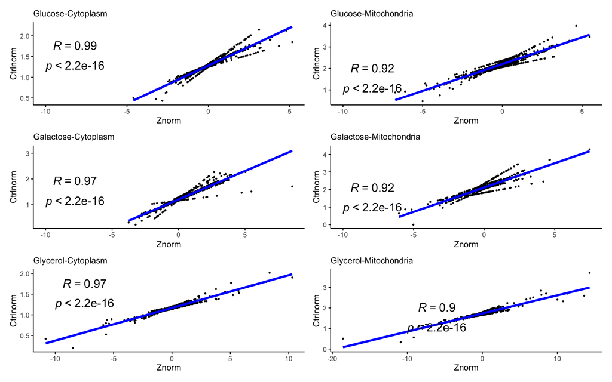

```r
p = plotList$`Glucose-Cytoplasm` + plotList$`Glucose-Mitochondria` + plotList$`Galactose-Cytoplasm` +
    plotList$`Galactose-Mitochondria` + plotList$`Glycerol-Cytoplasm` + plotList$`Glycerol-Mitochondria` +
    plot_layout(nrow = 3, ncol = 2)

ggsave(filename = paste0(path, "analysis/normalization/Correlation_among_normalizatin_methods_All.pdf"),
    plot = p, width = 5, height = 7)

p
```

Plotting the correlation between the two normalization techniques using ONLY the top hits 5% (high/low) roGFP2 ratios from either normalization method

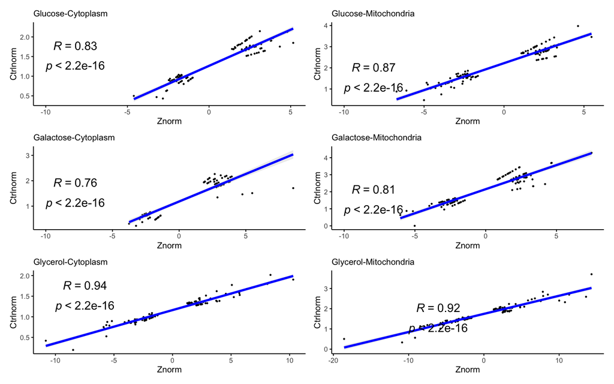

```r
p = plotListTop$`Glucose-Cytoplasm` + plotListTop$`Glucose-Mitochondria` + plotListTop$`Galactose-Cytoplasm` +
    plotListTop$`Galactose-Mitochondria` + plotListTop$`Glycerol-Cytoplasm` + plotListTop$`Glycerol-Mitochondria` +
    plot_layout(nrow = 3, ncol = 2)

ggsave(filename = paste0(path, "analysis/normalization/Correlation_among_normalizatin_methods_TopHits.pdf"),
    plot = p, width = 5, height = 7)

p
```

## Sample similarity - Dimensionality reduction

Next, we apply the dimensionality reduction method **Multidimesional scaling (MDS)** on the roGFP2 ratio values *normalized by the plate control* and *Robust Z normalized* to identify the major grouping of the yeast mutants based on their redox status across organelle and nutrient conditions.

> NOTE: I am also including the plots for *Robust Z normalized* simply to highlight that for this analysis, using *Robust Z normalized* is NOT appropriate.

We distinctly see from *plate control normalized* data that the redox status is different between the organelles (higher in mitochondria compared to cytoplasm) and within the organelles the mutants group by the nutrient conditions.

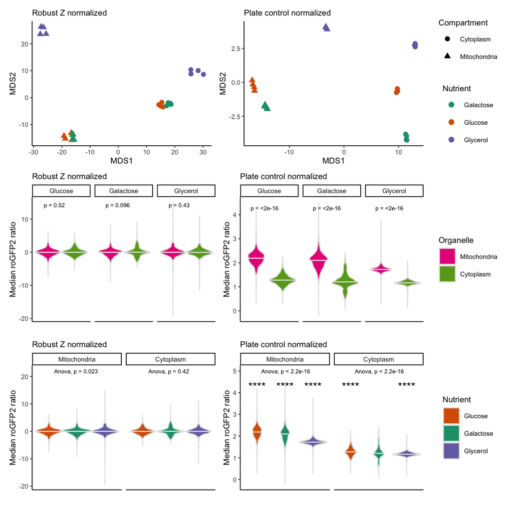

```r
getMDSdata = function(dat) {
    mds = cmdscale(dist(t(dat)), eig = TRUE, k = 2)$points
    colnames(mds) = c("MDS1", "MDS2")

    col_anno = do.call("rbind", strsplit(rownames(mds), "_"))
    col_anno = col_anno[, -c(1:3)]
    colnames(col_anno) = c("Compartment", "Nutrient")
    mds = data.frame(mds, col_anno)
}

mdsZ = getMDSdata(dat = normDat.Znorm$redox_replicates)
mdsC = getMDSdata(dat = normDat.ctrNorm$redox_replicates)

p1 = ggplot(mdsZ, aes(x = MDS1, y = MDS2)) + theme_classic(base_size = 8) + labs(subtitle = "Robust Z normalized") +
    geom_point(aes(color = Nutrient, shape = Compartment), size = 2) + scale_color_manual(values = c("#1B9E77",
    "#D95F02", "#7570B3"))

p2 = ggplot(mdsC, aes(x = MDS1, y = MDS2)) + theme_classic(base_size = 8) + labs(subtitle = "Plate control normalized") +
    geom_point(aes(color = Nutrient, shape = Compartment), size = 2) + scale_color_manual(values = c("#1B9E77",
    "#D95F02", "#7570B3"))

pA = p1 + p2 + plot_layout(guides = "collect")

p3 <- ggviolin(normDat.Znorm$redox_table, x = "Organelle", y = "Median_roGFP2_ratio",
    xlab = "", ylab = "Median roGFP2 ratio", draw_quantiles = 0.5, fill = "Organelle",
    facet.by = "Nutrient", color = "grey90") + stat_compare_means(label = "p.format",
    method = "wilcox", cex = 2) + labs(subtitle = "Robust Z normalized") + theme_classic(base_size = 8) +
    theme(legend.position = "right", axis.text.x = element_blank(), axis.ticks.x = element_blank()) +
    scale_fill_manual(values = c("#E7298A", "#66A61E"))

p4 <- ggviolin(normDat.ctrNorm$redox_table, x = "Organelle", y = "Median_roGFP2_ratio",
    xlab = "", ylab = "Median roGFP2 ratio", draw_quantiles = 0.5, fill = "Organelle",
    facet.by = "Nutrient", color = "grey90") + stat_compare_means(label = "p.format",
    method = "wilcox", cex = 2) + labs(subtitle = "Plate control normalized") + theme_classic(base_size = 8) +
    theme(legend.position = "right", axis.text.x = element_blank(), axis.ticks.x = element_blank()) +
    scale_fill_manual(values = c("#E7298A", "#66A61E"))

pB = p3 + p4 + plot_layout(guides = "collect")

p5 = ggviolin(normDat.Znorm$redox_table, x = "Nutrient", y = "Median_roGFP2_ratio",
    xlab = "", ylab = "Median roGFP2 ratio", draw_quantiles = 0.5, fill = "Nutrient",
    facet.by = "Organelle", color = "grey90") + stat_compare_means(method = "anova",
    label.y = 22, label.x = 1.5, cex = 2) + stat_compare_means(label = "p.signif",
    method = "wilcox", ref.group = ".all.", hide.ns = TRUE) + scale_fill_manual(values = c("#D95F02",
    "#1B9E77", "#7570B3")) + labs(subtitle = "Robust Z normalized") + theme_classic(base_size = 8) +
    theme(legend.position = "right", axis.text.x = element_blank(), axis.ticks.x = element_blank())

p6 = ggviolin(normDat.ctrNorm$redox_table, x = "Nutrient", y = "Median_roGFP2_ratio",
    xlab = "", ylab = "Median roGFP2 ratio", draw_quantiles = 0.5, fill = "Nutrient",
    facet.by = "Organelle", color = "grey90") + stat_compare_means(method = "anova",
    label.y = 5, label.x = 1.5, cex = 2) + stat_compare_means(label = "p.signif",
    method = "wilcox", ref.group = ".all.", hide.ns = TRUE) + scale_fill_manual(values = c("#D95F02",
    "#1B9E77", "#7570B3")) + labs(subtitle = "Plate control normalized") + theme_classic(base_size = 8) +
    theme(legend.position = "right", axis.text.x = element_blank(), axis.ticks.x = element_blank())

pC = p5 + p6 + plot_layout(guides = "collect")

p = pA/pB/pC

ggsave(filename = paste0(path, "analysis/normalization/roGFP2_ratio_comparison_nutrient_compartments.pdf"),
    plot = p, width = 7, height = 7)

p
```

## Replicate similarity - Correlation

Below we show the correlation among replicates with *plate control based normalization*.

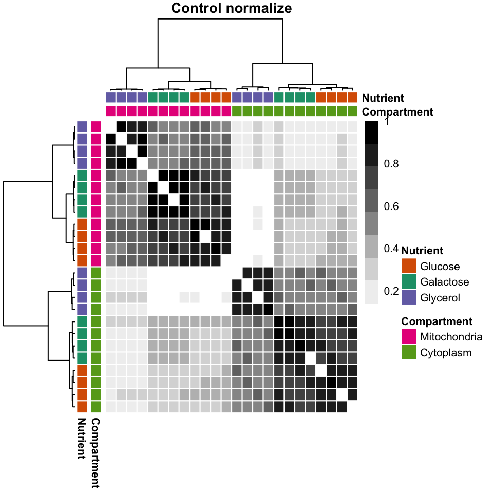

```r
c1 = cor(normDat.ctrNorm$redox_replicates, method = "spearman", use = "pairwise.complete.obs")

col_anno = do.call("rbind", strsplit(colnames(c1), "_"))
col_anno = col_anno[, -c(1:3)]
colnames(col_anno) = c("Compartment", "Nutrient")
rownames(col_anno) = colnames(c1)
col_anno = data.frame(col_anno, stringsAsFactors = F)

colr = list(Compartment = c(Mitochondria = "#E7298A", Cytoplasm = "#66A61E"), Nutrient = c(Glucose = "#D95F02",
    Galactose = "#1B9E77", Glycerol = "#7570B3"))

c1[c1 == 1] = NA

pheatmap(c1, clustering_method = "ward.D2", color = brewer.pal(n = 9, "Greys"), show_rownames = F,
    show_colnames = F, border_color = "white", na_col = "white", annotation_row = col_anno,
    annotation_col = col_anno, annotation_colors = colr, fontsize = 8, main = "Control normalize")
```

```r
pheatmap(c1, clustering_method = "ward.D2", color = brewer.pal(n = 9, "Greys"), show_rownames = F,
    show_colnames = F, border_color = "white", na_col = "white", annotation_row = col_anno,
    annotation_col = col_anno, annotation_colors = colr, fontsize = 8, filename = paste0(path,
        "analysis/normalization/replicate_correlation_normCtr.pdf"), width = 5, height = 5)
```

## Distribution of normalized data

- For per plate normalization based on plate specific control and an interactive data table to access the data

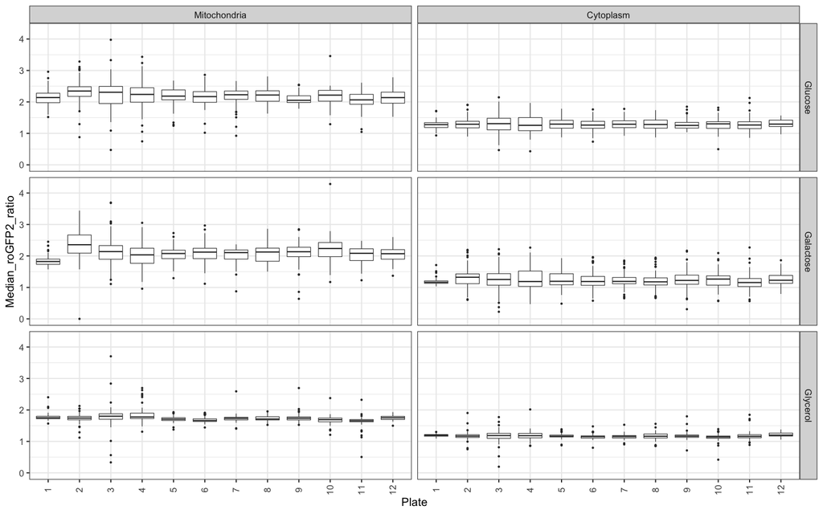

```r
p = ggplot(normDat.ctrNorm$redox_table) + theme_bw(base_size = 8) +
geom_boxplot(aes(x = Plate, y = Median_roGFP2_ratio), outlier.size = 0.1, lwd=0.2) + #ylim(-10, 10) +
facet_grid(Nutrient ~ Organelle) +
#geom_text_repel(data = subset(normDat.ctrNorm$redox_table, Median_roGFP2_ratio > 2.5 | Median_roGFP2_ratio < 1), aes(x = Plate, y = Median_roGFP2_ratio, label = Genes), size = 2) +
theme(axis.text.x = element_text(angle = 90, hjust = 0.5, vjust = 0.5))

ggsave(filename = paste0(path,"analysis/normalization/roGFP2_ratio_distribution_PlateControl_normalized.pdf"),
       plot = p, width = 7, height = 7)
p
```

```r
tmp = normDat.ctrNorm$redox_table
tmp[,5:9] = round(tmp[,5:9],3)

datatable(tmp, rownames = FALSE, filter="top", class="compact",
          extensions = c('Buttons') ,
          options = list(autoWidth = TRUE,
                          dom = 'Bfrtip',
                          buttons = c('csv', 'excel')
                         ))
```

| Genes | Plate | Nutrient | Organelle | roGFP2_ratio_1 | roGFP2_ratio_2 | roGFP2_ratio_3 | roGFP2_ratio_4 | Median_roGFP2_ratio |
| --- | --- | --- | --- | --- | --- | --- | --- | --- |
| ALG2 | 1 | Galactose | Cytoplasm | 1.046 | 1.053 | 1.039 | 1.036 | 1.043 |
| BRN1 | 1 | Galactose | Cytoplasm | 1.38 | 1.345 | 1.346 | 1.296 | 1.345 |
| CCA1 | 1 | Galactose | Cytoplasm | 1.179 | 1.163 | 1.218 | 1.189 | 1.184 |
| CCT2 | 1 | Galactose | Cytoplasm | 1.052 | 1.071 | 1.062 | 1.046 | 1.057 |
| CCT3 | 1 | Galactose | Cytoplasm | 1.164 | 1.161 | 1.16 | 1.165 | 1.162 |
| CDC53 | 1 | Galactose | Cytoplasm | 1.227 | 1.2 | 1.234 | 1.273 | 1.231 |
| DSN1 | 1 | Galactose | Cytoplasm | 1.076 | 1.111 | 1.083 | 1.057 | 1.079 |
| EBP2 | 1 | Galactose | Cytoplasm | 1.293 | 1.312 | 1.271 | 1.306 | 1.299 |
| HSF1 | 1 | Galactose | Cytoplasm | 1.301 | 1.254 | 1.263 | 1.299 | 1.281 |
| LSG1 | 1 | Galactose | Cytoplasm | 1.154 | 1.067 | 1.135 | 1.137 | 1.136 |

[output cut: 4457 more lines]

- For per plate normalization based on median organelle specific values and an interactive data table to access the data

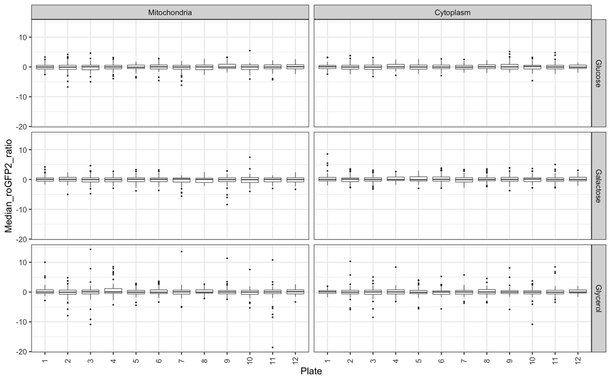

```r
p = ggplot(normDat.Znorm$redox_table) + theme_bw(base_size = 9) + #geom_hline(yintercept = c(-5,5)) +
geom_boxplot(aes(x = Plate, y = Median_roGFP2_ratio), outlier.size = 0.1, lwd = 0.2) + #ylim(-10, 10) +
facet_grid(Nutrient ~ Organelle) +
#geom_text_repel(data = subset(normDat.Znorm$redox_table, Median_roGFP2_ratio > 3 | Median_roGFP2_ratio < -3), aes(x = Plate, y = Median_roGFP2_ratio, label = Genes), size = 2) +
theme(axis.text.x = element_text(angle = 90, hjust = 0.5, vjust = 0.5))

ggsave(filename = paste0(path,"analysis/normalization/roGFP2_ratio_distribution_RobustZ_normalized.pdf"),
       plot = p, width = 7, height = 7)
p
```

```r
tmp = normDat.Znorm$redox_table
tmp[,5:9] = round(tmp[,5:9],3)

datatable(tmp, rownames = FALSE, filter="top", class="compact",
          extensions = c('Buttons') ,
          options = list(autoWidth = TRUE,
                          dom = 'Bfrtip',
                          buttons = c('csv', 'excel')
                         ))
```

| Genes | Plate | Nutrient | Organelle | roGFP2_ratio_1 | roGFP2_ratio_2 | roGFP2_ratio_3 | roGFP2_ratio_4 | Median_roGFP2_ratio |
| --- | --- | --- | --- | --- | --- | --- | --- | --- |
| ALG2 | 1 | Glucose | Cytoplasm | -1.745 | -1.513 | -1.637 | -1.904 | -1.691 |
| BRN1 | 1 | Glucose | Cytoplasm | 2.413 | 1.963 | 1.423 | 0.179 | 1.693 |
| CCA1 | 1 | Glucose | Cytoplasm | -0.348 | -1.501 | 0.635 | -0.454 | -0.401 |
| CCT2 | 1 | Glucose | Cytoplasm | 0.459 | -0.112 | 0.444 | -0.342 | 0.166 |
| CCT3 | 1 | Glucose | Cytoplasm | -0.337 | -0.348 | -0.348 | -0.598 | -0.348 |
| CDC53 | 1 | Glucose | Cytoplasm | 0.81 | 0.386 | 1.369 | 1.64 | 1.09 |
| DSN1 | 1 | Glucose | Cytoplasm | 0.383 | 0.608 | -0.298 | -0.763 | 0.042 |
| EBP2 | 1 | Glucose | Cytoplasm | 0.35 | 0.719 | -2.012 | -1.552 | -0.601 |
| HSF1 | 1 | Glucose | Cytoplasm | 1.815 | 0.324 | 0.128 | 1.487 | 0.905 |
| LSG1 | 1 | Glucose | Cytoplasm | 0.27 | -0.906 | -0.464 | -0.603 | -0.533 |

[output cut: 4473 more lines]

## Saving the data

Finally we save the normalized data as a `.RDS` (R data object) and `.xlsx` excel data file. All our follow up downstream analysis will start from these normalized data.

```r
saveRDS(normDat.ctrNorm, paste0(path, "data/workspaces/YeastRedox_DAmP_PlateControl_NormalizedData.RDS"))
saveRDS(normDat.Znorm, paste0(path, "data/workspaces/YeastRedox_DAmP_RobustZ_NormalizedData.RDS"))

WriteXLS(normDat.ctrNorm$redox_table, ExcelFileName = paste0(path, "analysis/supplementary/tables/YeastRedox_DAmP_PlateControl_NormalizedData.xlsx"),
    AdjWidth = TRUE, BoldHeaderRow = TRUE, FreezeRow = 1)

WriteXLS(normDat.Znorm$redox_table, ExcelFileName = paste0(path, "analysis/supplementary/tables/YeastRedox_DAmP_RobustZ_NormalizedData.xlsx"),
    AdjWidth = TRUE, BoldHeaderRow = TRUE, FreezeRow = 1)
```

Ashwini Kumar Sharma, PhD

2021-06-18